# Entrega Final - Series Cronológicas

Facultad de Ciencias Económicas y Administración - 2025 - UDeLaR

Author

Leandro Berrueta, Lucca Frachelle, Cecilia Waksman

Published

June 19, 2025

Se dispone de una serie mensual con la cantidad de clientes con deuda vigente en el Banco Santander en el período Diciembre - 2018 a Marzo - 2025.

Una primera visualización de la serie permite identificar una clara tendencia creciente a lo largo del tiempo, especialmente a partir de 2020, con un aumento significativo hacia 2024.

En principio no se logra reconocer un comportamiento estacional evidente o un patrón repetitivo a intervalos fijos en la serie.

La variabilidad parece aumentar ligeramente con el nivel de la serie, lo que podría sugerir la necesidad de aplicar una transformación logarítmica a modo de homogeneizar la Varianza de la serie. El uso de dicha transformación se evaluará más adelante tomando como insumo el comportamiento de los residuos.

# 1 Análisis Inicial

## 1.1 Gráfico de la Serie Temporal

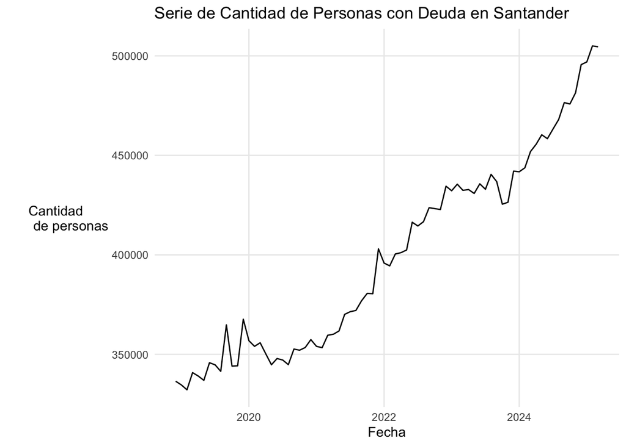

## 1.2 Estadísticas Descriptivas

Estadísticas Descriptivas de la Serie de Cantidad de Personas con Deuda

| Estadística | Valor |
| --- | --- |
| Min. | 332198 |
| 1st Qu. | 353424 |
| Median | 398162 |
| Mean | 399505 |
| 3rd Qu. | 435553 |
| Max. | 504989 |

# 2 Identificación del Modelo

## 2.1 Análisis en el Dominio del Tiempo

### 2.1.1 Función de Autocorrelación (FAC)

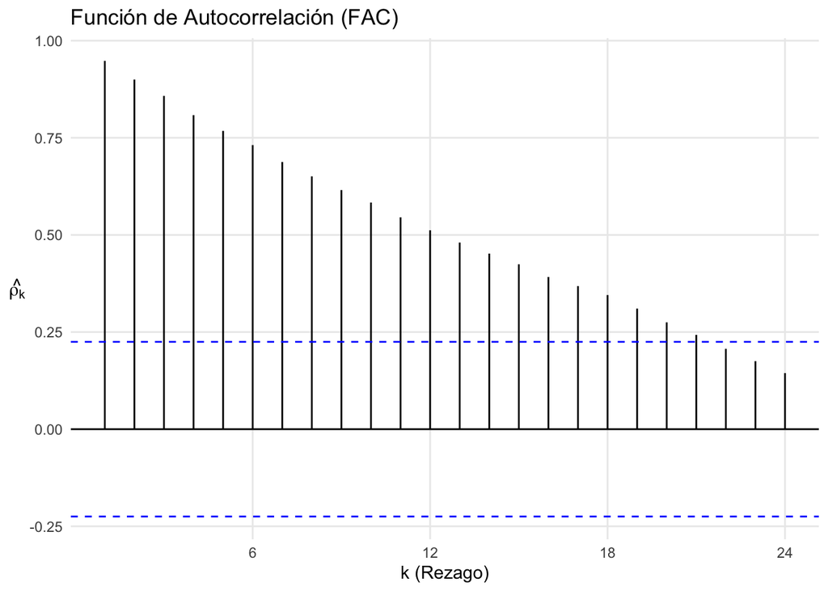

Se observa que la Función de Aucorrelación (FAC) decrece lentamente y de forma persistente, con coeficientes de autocorrelación significativos que se mantienen altos incluso en rezagos grandes y que, por ende, no se comportan de acuerdo al decaimiento exponencial que caracteriza a las series débilmente estacionarias[^1]. Esto es un fuerte indicio de que la serie no es estacionaria.

Además, las autocorrelaciones significativas en rezagos altos sugieren la presencia de una tendencia, detalle claramente observable al inspeccionar el gráfico de la serie.

### 2.1.2 Función de Autocorrelación Parcial (FACP)

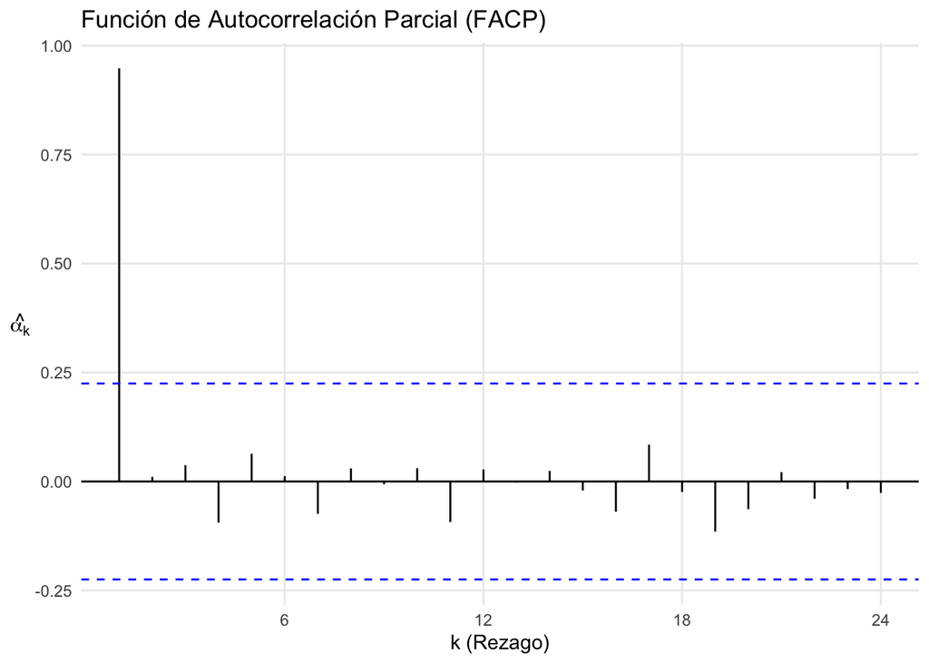

La Función de Aucorrelación Parcial (FACP) muestra un coeficiente significativo en el primer rezago y luego decae rápidamente, no habiendo otro rezago que resulte significativo al nivel de significación usual del 5%.

Esto podría sugerir un componente AR(1) si la serie fuera estacionaria. Sin embargo, dada la FAC planteada anteriormente, se concluye de este primer análisis del Dominio del Tiempo en la necesidad de aplicar, al menos, una primera diferencia regular a la serie.

## 2.2 Análisis en el Dominio de Frecuencias

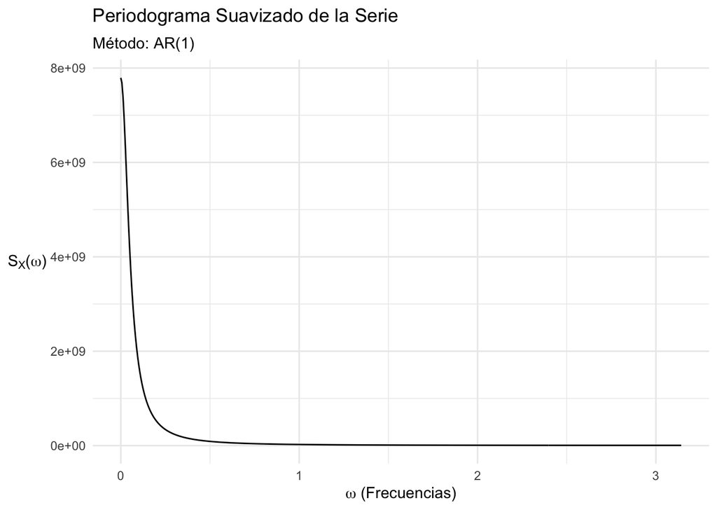

Mediante el Periodograma Suavizado de la serie es posible respaldar la idea de que la misma presenta una tendencia que debería ser modelada.

En particular, las frecuencias más próximas a 0, y por ende las asociadas a ciclos de período próximo a infinito (el componente tendencial) explica la mayor parte de la variabilidad de la serie[^2].

## 2.3 Serie Diferenciada de acuerdo a la Primera Diferencia Regular

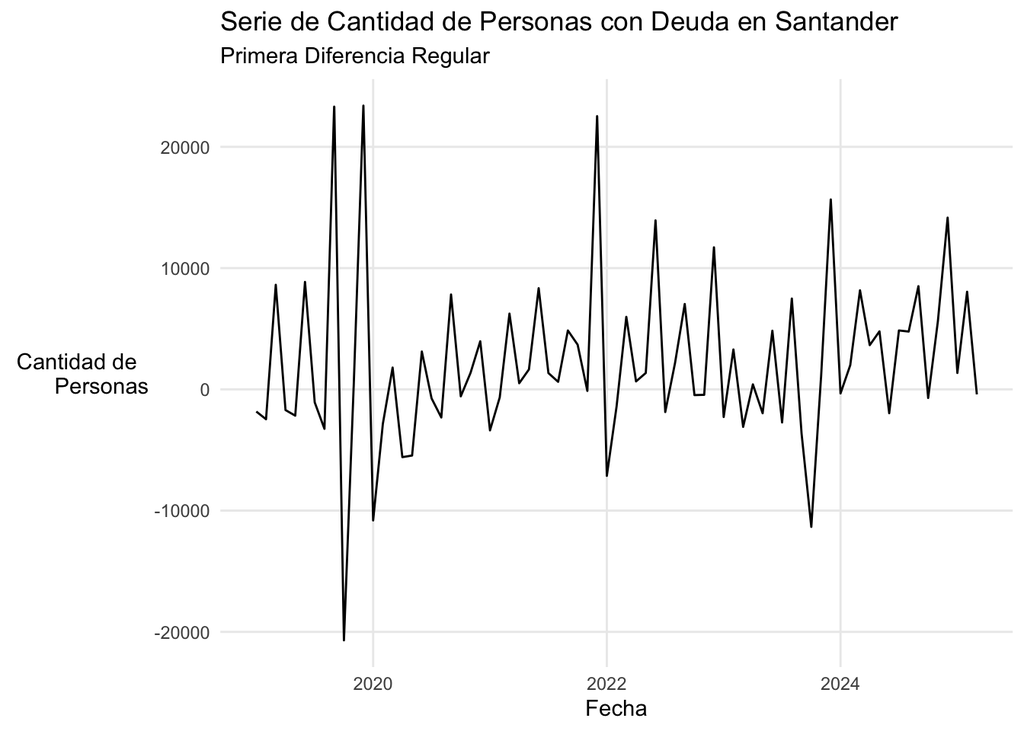

## 2.4 FAC y FACP de la Serie Diferenciada

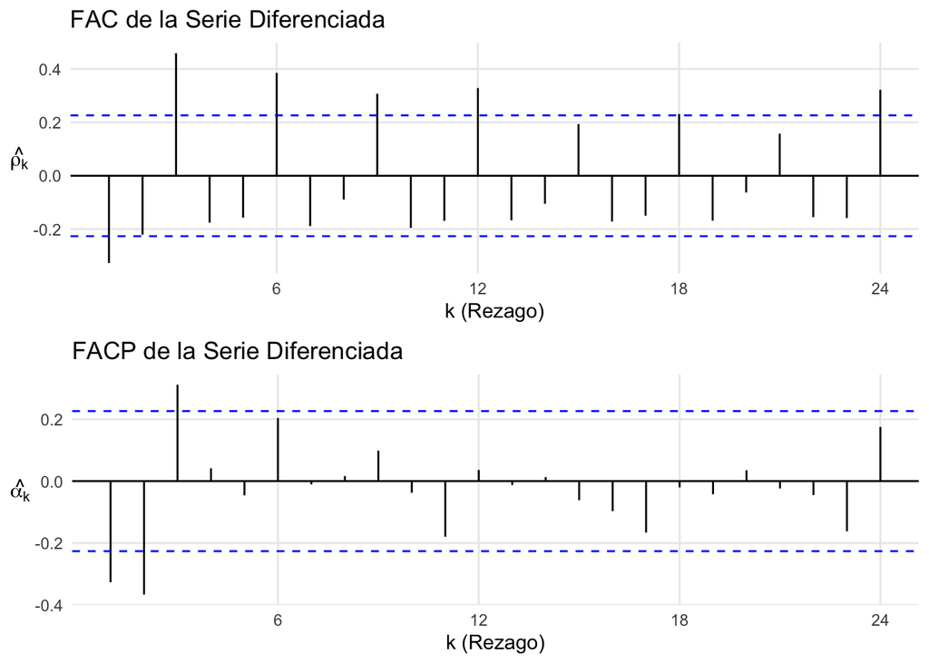

Específicamente, se nota la presencia de coeficientes significativos en el rezago 3, en el rezago 6 y en el rezago 9, con una rápida aproximación a las bandas de confianza[^3].

De esta manera se puede destacar que las observaciones se encuentran autocorrelacionadas con sus valores de 3, 6 y 9 meses atrás. Dado que estos rezagos son múltiplos de 3 es que se plantea modelar una estacionalidad de tipo trimestral. Para ello se aplicará una Primera Diferencia Estacional asociada al rezago $k = 3$.

## 2.5 Serie Diferenciada de acuerdo a la Primera Diferencia Regular y Primera Diferencia Estacional (Trimestral)

## 2.6 Gráfico de la Serie Diferenciada Estacional

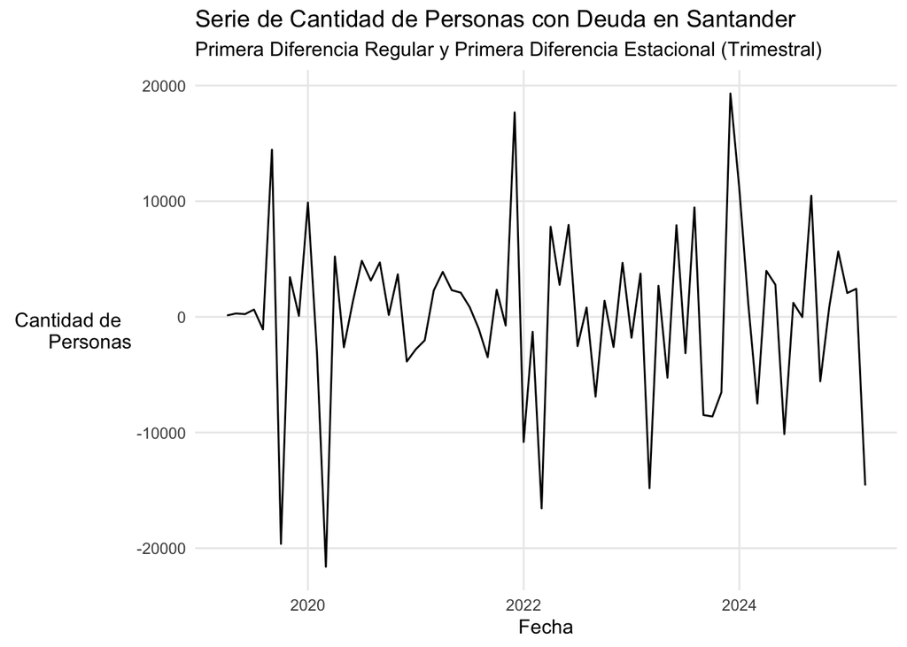

## 2.7 FAC y FACP de la Serie Diferenciada (Regular y Estacional)

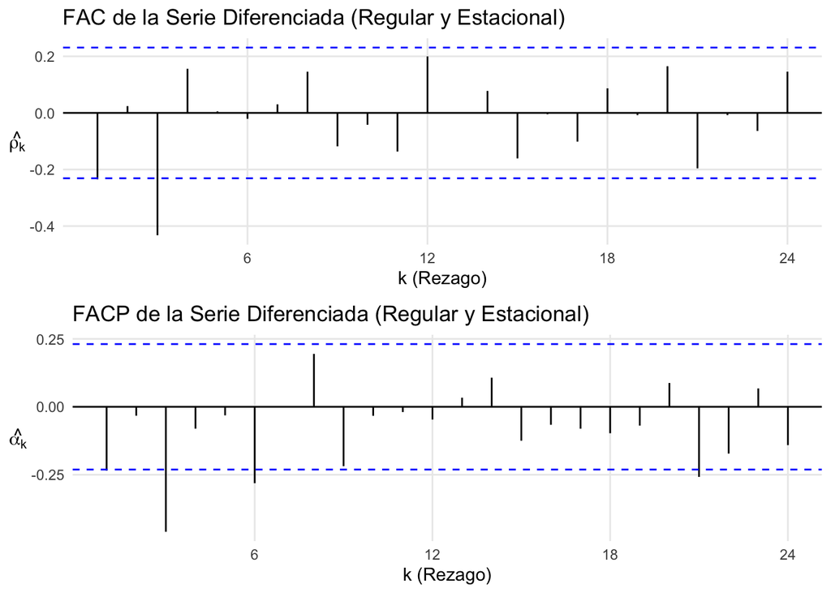

# 3 Modelos Propuesto

## 3.1 Comparación de Modelos SARIMA

Comparación de Modelos SARIMA Ordenados por BIC

| Modelo | AIC | AICc | BIC | RMSE |
| --- | --- | --- | --- | --- |
| SARIMA(1,1,1)(0,1,1)[3] | 1460.32 | 1460.92 | 1469.43 | 5513.89 |
| SARIMA(1,1,1)(1,1,1)[3] | 1461.83 | 1462.74 | 1473.22 | 5493.50 |
| SARIMA(2,1,2)(1,1,1)[3] | 1462.76 | 1464.51 | 1478.70 | 5251.20 |
| SARIMA(1,1,1)(1,1,0)[3] | 1472.51 | 1473.10 | 1481.61 | 6109.84 |
| SARIMA(1,1,1)(0,1,0)[3] | 1479.30 | 1479.65 | 1486.13 | 6478.65 |
| SARIMA(0,1,1)(0,1,0)[3] | 1485.29 | 1485.47 | 1489.85 | 6896.30 |
| SARIMA(2,1,1)(0,1,0)[3] | 1481.28 | 1481.88 | 1490.39 | 6477.11 |
| SARIMA(1,1,2)(0,1,0)[3] | 1481.29 | 1481.88 | 1490.39 | 6477.71 |
| SARIMA(2,1,2)(0,1,0)[3] | 1480.05 | 1480.96 | 1491.44 | 6325.73 |
| SARIMA(1,1,0)(0,1,0)[3] | 1487.74 | 1487.91 | 1492.29 | 7026.04 |

Se elige el modelo SARIMA(1,1,1)(0,1,1)[3] por el criterio BIC.

## 3.2 Coeficientes del Modelo SARIMA

Coeficientes del Modelo SARIMA(1,1,1)(0,1,1)[3]

| **Término** | **Beta**<sup>1</sup> | **SE** |
| --- | --- | --- |
| ar1 | 0.03 | 0.350 |
| ma1 | -0.27 | 0.329 |
| sma1 | -0.83*** | 0.082 |

Abbreviations: CI = Confidence Interval, SE = Standard Error  
<sup>1</sup> *p<0.05; **p<0.01; ***p<0.001

Como los coeficientes de la constante y el AR(1) y MA(1) no son significativos, pero el componente estacional es significativo, se va a explorar el modelo SARIMA(0,1,0)(0,1,1)[3]

Coeficientes del Modelo SARIMA(0,1,0)(0,1,1)[3]

| **Término** | **Beta**<sup>1</sup> | **SE** |
| --- | --- | --- |
| sma1 | -0.83*** | 0.076 |

Abbreviations: CI = Confidence Interval, SE = Standard Error  
<sup>1</sup> *p<0.05; **p<0.01; ***p<0.001

## 3.3 Criterios de Información del Modelo

Criterios de Información del Modelo SARIMA(0,1,0)(0,1,1)[3]

| AIC | AICc | BIC |
| --- | --- | --- |
| 1460.303 | 1460.477 | 1464.857 |

## 3.4 Medidas de Error del Modelo

Medidas de Error del Modelo SARIMA(0,1,0)(0,1,1)[3] en el Conjunto de Entrenamiento

| Conjunto | ME | RMSE | MAE | MPE | MAPE | MASE | ACF1 |
| --- | --- | --- | --- | --- | --- | --- | --- |
| Training set | 370.4661 | 5667.94 | 4062.324 | 0.0752766 | 1.018512 | 0.1540476 | -0.2199793 |

## 3.5 Pruebas de Raíz Unitaria

Resultados de las Pruebas de Raíz Unitaria (ADF y KPSS) en los Residuos del Modelo

| Test | Statistic | p_value | Method |
| --- | --- | --- | --- |
| ADF Test | -3.4797480 | 0.0495907 | Augmented Dickey-Fuller Test |
| KPSS Test | 0.1339157 | 0.1000000 | KPSS Test for Level Stationarity |

# 4 Diagnóstico de los Residuos del Modelo Propuesto

## 4.1 Gráfico de Residuos

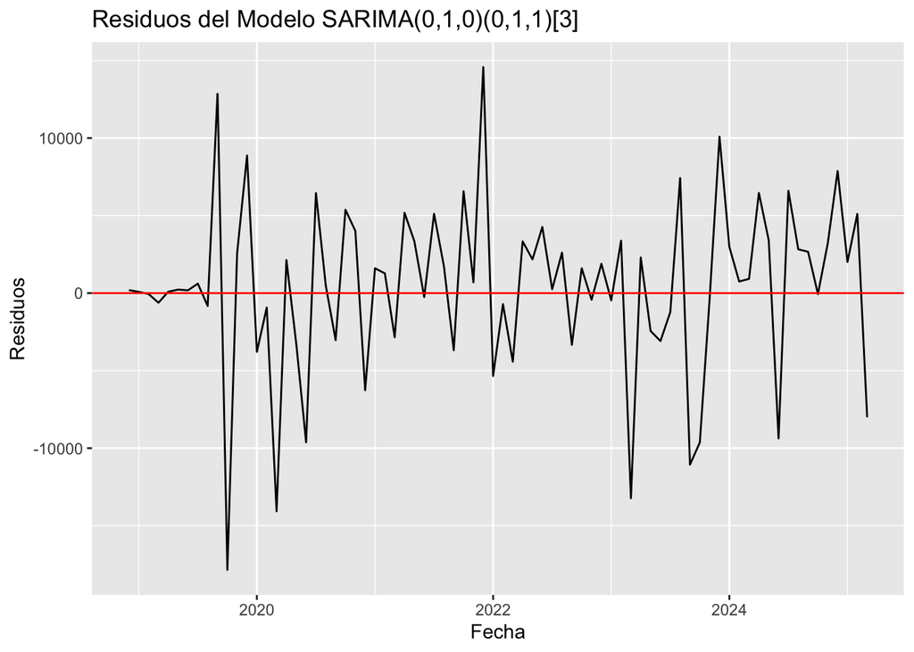

## 4.2 FAC y FACP de los Residuos

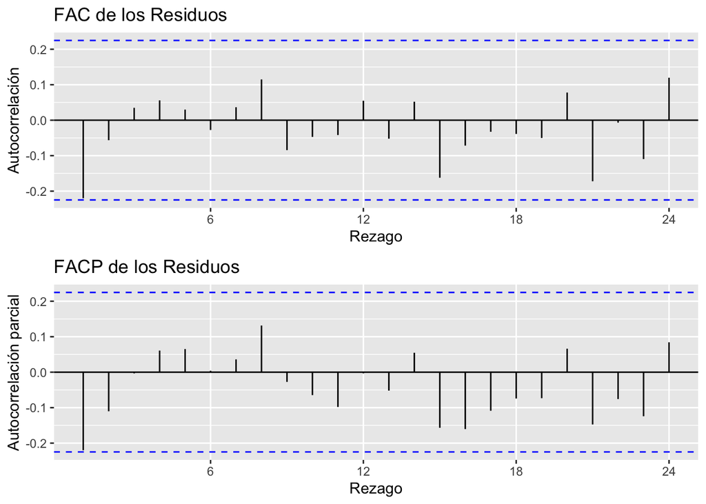

## 4.3 Test de Ljung-Box

Resultados del Test de Ljung-Box

| Test | Estadistico | p_value | Metodo | Parametro |
| --- | --- | --- | --- | --- |
| Ljung-Box (Lag 10) | 6.668533 | 0.4641881 | Box-Ljung test | 7 |
| Ljung-Box (Lag 20) | 11.852580 | 0.8089807 | Box-Ljung test | 17 |

## 4.4 Análisis de Homocedasticidad

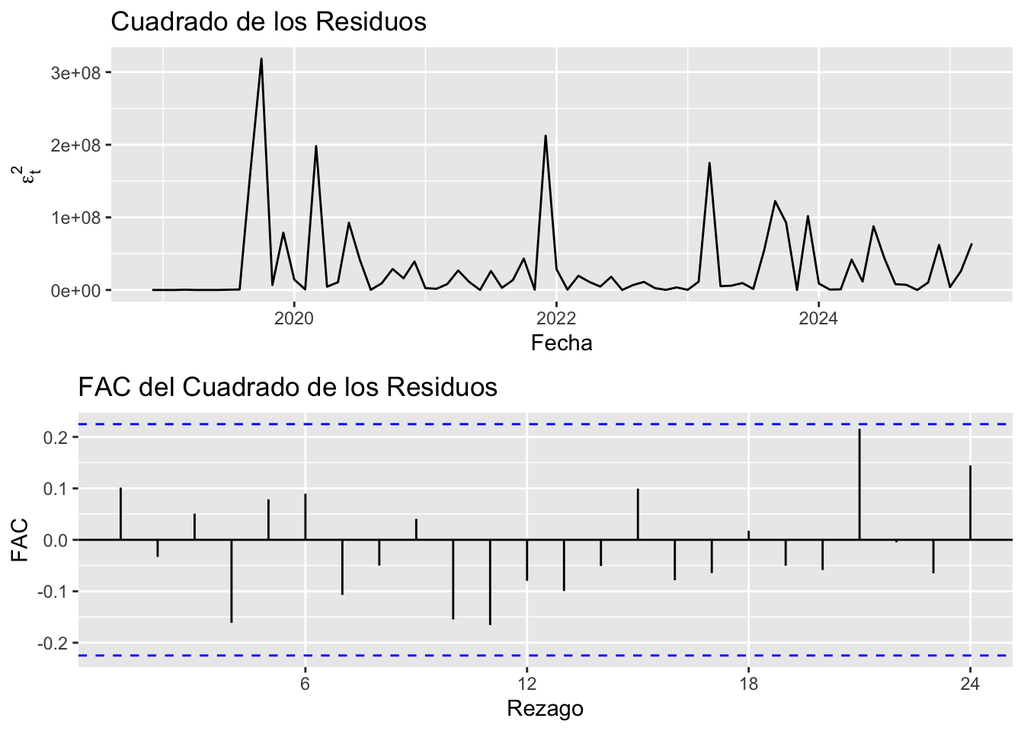

## 4.5 Análisis de Normalidad

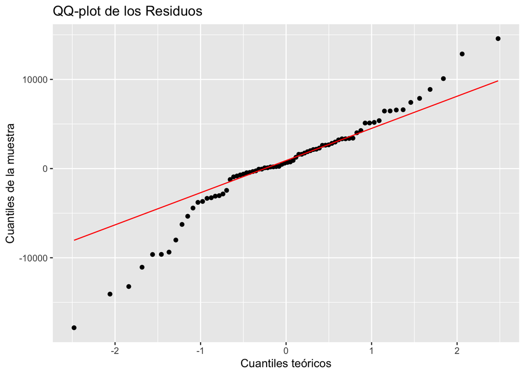

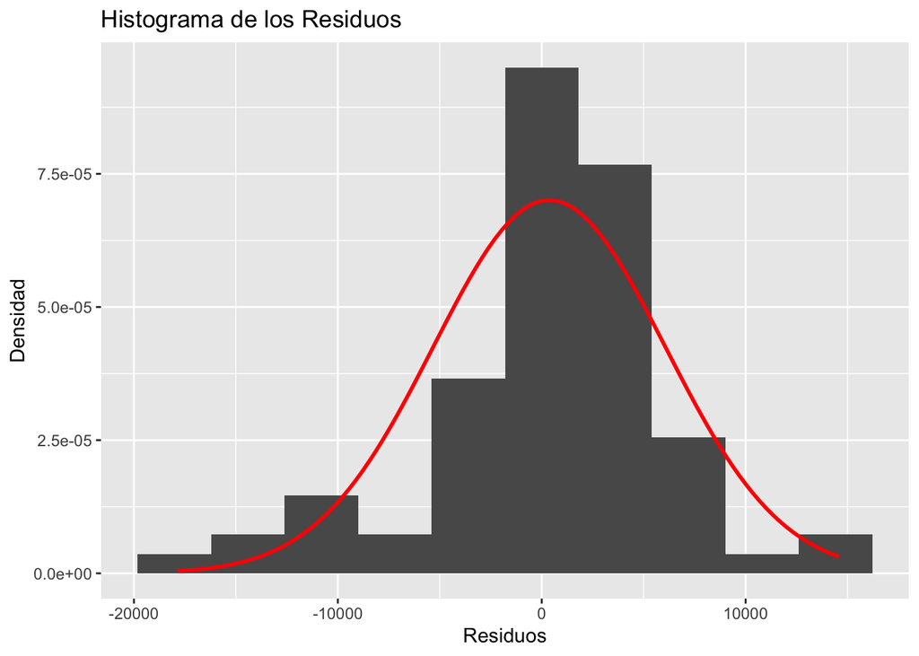

## 4.6 Tests de Normalidad

Resultados de los Tests de Normalidad

| Test | Estadistico | p_value | Metodo |
| --- | --- | --- | --- |
| Shapiro-Wilk | 0.9518584 | 0.0058742 | Shapiro-Wilk normality test |
| Jarque-Bera | 10.7723211 | 0.0045795 | Jarque Bera Test |

## Footnotes

[^1]: En el presente trabajo se utilizará como sinónimos “estacionariedad en sentido débil”, “estacionariedad en covarianza” y “estacionariedad”, al igual que se hizo durante el desarrollo del curso.
[^2]: Corresponde resaltar, sin embargo, que la relación entre el área que se encuentra por debajo del Espectro/Periodograma y la Varianza de la serie se plantea para series estacionarias, propiedad que claramente no caracteriza a la serie en tratamiento.
[^3]: El coeficiente asociado al rezago 12 también es significativo, aunque como su magnitud es mayor a la del coeficiente del rezago 9 se decide, en principio, trabajar con los rezagos $k = 3, 6, 9$. Si bien 12 es múltiplo de 3 y por ende su significación puede estar ligada a la trimestralidad, no se debe descartar que pueda existir un componente de estacionalidad anual.